# 06.01-pyplot-tutorial

## Matplotlib

**`matplotlib`** 是一個 **`Python`** 的 `2D` 圖形包。

## 使用 Pyplot

```python
import numpy as np
import matplotlib.pyplot as plt
```

`matplotlib.pyplot` 包含一系列類似 **`MATLAB`** 中繪圖函數的相關函數。每個 `matplotlib.pyplot` 中的函數對當前的圖像進行一些修改，例如：產生新的圖像，在圖像中產生新的繪圖區域，在繪圖區域中畫線，給繪圖加上標記，等等…… `matplotlib.pyplot` 會自動記住當前的圖像和繪圖區域，因此這些函數會直接作用在當前的圖像上。

下文中，以 `plt` 作為 `matplotlib.pyplot` 的省略。

## plt.show() 函數

預設情況下，`matplotlib.pyplot` 不會直接顯示圖像，只有調用 `plt.show()` 函數時，圖像才會顯示出來。

`plt.show()` 預設是在新視窗打開一幅圖像，並且提供了對圖像進行操作的按鈕。

不過在 `ipython` 命令列中，我們可以使用 `magic` 命令將它插入 `notebook` 中，並且不需要調用 `plt.show()` 也可以顯示：

- `%matplotlib notebook`
- `%matplotlib inline`

不過在實際寫程式中，我們還是需要調用 `plt.show()` 函數將圖像顯示出來。

這裡我們使圖像輸出在 `notebook` 中：

```python
%matplotlib inline
```

## plt.plot() 函數

`plt.plot()` 函數可以用來繪圖：

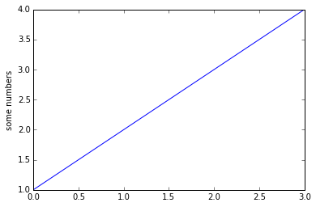

```python
plt.plot([1,2,3,4])
plt.ylabel('some numbers')

plt.show()
```

### 基本用法

`plot` 函數基本的用法有以下四種：

預設參數

- `plt.plot(x,y)`

指定參數

- `plt.plot(x,y, format_str)`

預設參數，`x` 為 `0~N-1`

- `plt.plot(y)`

指定參數，`x` 為 `0~N-1`

- `plt.plot(y, format_str)`

因此，在上面的例子中，我們沒有給定 `x` 的值，所以其預設值為 `[0,1,2,3]`。

傳入 `x` 和 `y`：

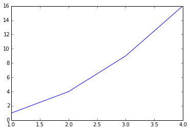

```python
plt.plot([1,2,3,4], [1,4,9,16])
```

### 字元参数

和 **`MATLAB`** 中類似，我們還可以用字元來指定繪圖的格式：

表示顏色的字元參數有：

| 字元 | 顏色 |
| --- | --- |
| `‘b’` | 藍色，blue |
| `‘g’` | 綠色，green |
| `‘r’` | 紅色，red |
| `‘c’` | 青色，cyan |
| `‘m’` | 品紅，magenta |
| `‘y’` | 黃色，yellow |
| `‘k’` | 黑色，black |
| `‘w’` | 白色，white |

表示類型的字元參數有：

| 字元 | 類型 | 字元 | 類型 |
| --- | --- | --- | --- |
| `'-'` | 實線 | `'--'` | 虛線 |
| `'-.'` | 虛點線 | `':'` | 點線 |
| `'.'` | 點 | `','` | 圖元點 |
| `'o'` | 圓點 | `'v'` | 下三角點 |
| `'^'` | 上三角點 | `'<'` | 左三角點 |
| `'>'` | 右三角點 | `'1'` | 下三叉點 |
| `'2'` | 上三叉點 | `'3'` | 左三叉點 |
| `'4'` | 右三叉點 | `'s'` | 正方點 |
| `'p'` | 五角點 | `'*'` | 星形點 |
| `'h'` | 六邊形點1 | `'H'` | 六邊形點2 |
| `'+'` | 加號點 | `'x'` | 乘號點 |
| `'D'` | 實心菱形點 | `'d'` | 瘦菱形點 |
| `'_'` | 橫線點 |  |  |

例如我們要畫出紅色圓點：

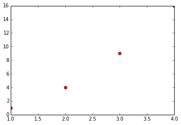

```python
plt.plot([1,2,3,4], [1,4,9,16], 'ro')
plt.show()
```

可以看出，有兩個點在圖像的邊緣，因此，我們還需要用下列做法改變軸的顯示範圍。

### 顯示範圍

可以使用 `axis` 函數指定坐標軸顯示的範圍：

```
plt.axis([xmin, xmax, ymin, ymax])
```

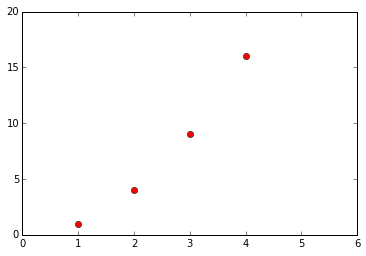

```python
plt.plot([1,2,3,4], [1,4,9,16], 'ro')
# 指定 x 轴显示区域为 0-6，y 轴为 0-20
plt.axis([0,6,0,20])
plt.show()
```

### 傳入 `Numpy` 陣列

之前我們傳給 `plot` 的參數都是串列，事實上，向 `plot` 中傳入 `numpy` 陣列是更常用的做法。事實上，如果傳入的是串列，`matplotlib` 會在內部將它轉化成陣列再進行處理：

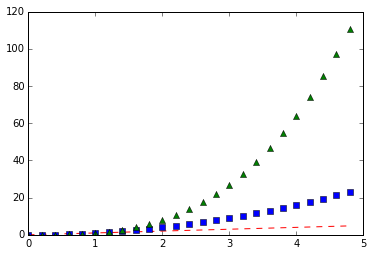

```python
import numpy as np
import matplotlib.pyplot as plt

# evenly sampled time at 200ms intervals
t = np.arange(0., 5., 0.2)

# red dashes, blue squares and green triangles
plt.plot(t, t, 'r--',
         t, t**2, 'bs',
         t, t**3, 'g^')

plt.show()
```

### 傳入多組資料

事實上，在上面的例子中，我們不僅僅向 `plot` 函數傳入了陣列，還傳入了多組 `(x,y,format_str)` 參數，它們在同一張圖上顯示。

這意味著我們不需要使用多個 `plot` 函數來畫多組陣列，只需要可以將這些組合放到一個 `plot` 函數中去即可。

### 線條屬性

之前提到，我們可以用字串來控制線條的屬性，事實上還可以通過關鍵字來改變線條的性質，例如 `linwidth` 可以改變線條的寬度，`color` 可以改變線條的顏色：

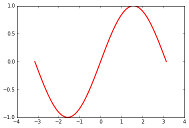

```python
x = np.linspace(-np.pi,np.pi)
y = np.sin(x)

plt.plot(x, y, linewidth=2.0, color='r')

plt.show()
```

### 使用 plt.plot() 的返回值來設置線條屬性

`plot` 函數返回一個 `Line2D` 物件組成的清單，每個物件代表輸入的一對組合，例如：

- line1, line2 為兩個 Line2D 對象

  `line1, line2 = plt.plot(x1, y1, x2, y2)`
- 返回 3 個 Line2D 物件組成的清單

  `lines = plt.plot(x1, y1, x2, y2, x3, y3)`

我們可以使用這個返回值來對線條屬性進行設置：

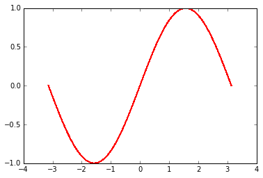

```python
# 加逗號 line 中得到的是 line2D 物件，不加逗號得到的是只有一個 line2D 物件的清單
line, = plt.plot(x, y, 'r-')

# 將抗鋸齒關閉
line.set_antialiased(False)

plt.show()
```

### plt.setp() 修改線條性質

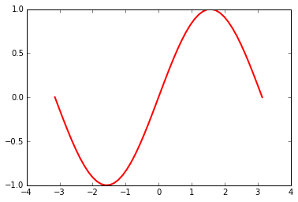

```python
lines = plt.plot(x, y)

# 使用鍵值對
plt.setp(lines, color='r', linewidth=2.0)

# 或者使用 MATLAB 風格的字串對
plt.setp(lines, 'color', 'r', 'linewidth', 2.0)

plt.show()
```

```python
plt.setp(lines)
```

```
  agg_filter: unknown
  alpha: float (0.0 transparent through 1.0 opaque)
  animated: [True | False]
  antialiased or aa: [True | False]
  axes: an :class:`~matplotlib.axes.Axes` instance
  clip_box: a :class:`matplotlib.transforms.Bbox` instance
  clip_on: [True | False]
  clip_path: [ (:class:`~matplotlib.path.Path`,         :class:`~matplotlib.transforms.Transform`) |         :class:`~matplotlib.patches.Patch` | None ]
  color or c: any matplotlib color
  contains: a callable function
  dash_capstyle: ['butt' | 'round' | 'projecting']
  dash_joinstyle: ['miter' | 'round' | 'bevel']
  dashes: sequence of on/off ink in points
  drawstyle: ['default' | 'steps' | 'steps-pre' | 'steps-mid' |                   'steps-post']
  figure: a :class:`matplotlib.figure.Figure` instance
  fillstyle: ['full' | 'left' | 'right' | 'bottom' | 'top' | 'none']
  gid: an id string
  label: string or anything printable with '%s' conversion.
  linestyle or ls: [``'-'`` | ``'--'`` | ``'-.'`` | ``':'`` | ``'None'`` |                   ``' '`` | ``''``]
  linewidth or lw: float value in points
  lod: [True | False]
  marker: :mod:`A valid marker style <matplotlib.markers>`
  markeredgecolor or mec: any matplotlib color
  markeredgewidth or mew: float value in points
  markerfacecolor or mfc: any matplotlib color
  markerfacecoloralt or mfcalt: any matplotlib color
  markersize or ms: float
  markevery: [None | int | length-2 tuple of int | slice |         list/array of int | float | length-2 tuple of float]
  path_effects: unknown
  picker: float distance in points or callable pick function         ``fn(artist, event)``
  pickradius: float distance in points
  rasterized: [True | False | None]
  sketch_params: unknown
  snap: unknown
  solid_capstyle: ['butt' | 'round' |  'projecting']
  solid_joinstyle: ['miter' | 'round' | 'bevel']
  transform: a :class:`matplotlib.transforms.Transform` instance
  url: a url string
  visible: [True | False]
  xdata: 1D array
  ydata: 1D array
  zorder: any number
```

## 子圖

`figure()` 函數會產生一個指定編號為 `num` 的圖：

```
plt.figure(num)
```

這裡，`figure(1)` 其實是可以省略的，因為預設情況下 `plt` 會自動產生一幅圖像。

使用 `subplot` 可以在一副圖中生成多個子圖，其參數為：

```
plt.subplot(numrows, numcols, fignum)
```

當 `numrows * numcols < 10` 時，中間的逗號可以省略，因此 `plt.subplot(211)` 就相當於 `plt.subplot(2,1,1)`。

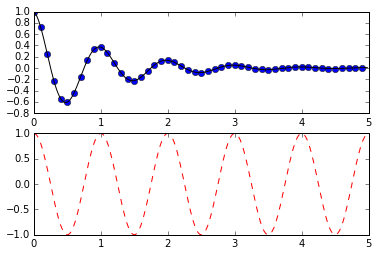

```python
def f(t):
    return np.exp(-t) * np.cos(2*np.pi*t)

t1 = np.arange(0.0, 5.0, 0.1)
t2 = np.arange(0.0, 5.0, 0.02)

plt.figure(1)
plt.subplot(211)
plt.plot(t1, f(t1), 'bo', t2, f(t2), 'k')

plt.subplot(212)
plt.plot(t2, np.cos(2*np.pi*t2), 'r--')
plt.show()
```

## 圖形上加上文字

`plt.hist()` 可以用來畫直方圖。

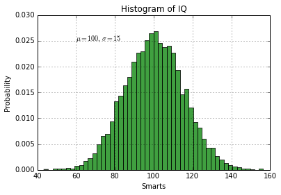

```python
mu, sigma = 100, 15
x = mu + sigma * np.random.randn(10000)

# the histogram of the data
n, bins, patches = plt.hist(x, 50, normed=1, facecolor='g', alpha=0.75)


plt.xlabel('Smarts')
plt.ylabel('Probability')
plt.title('Histogram of IQ')
plt.text(60, .025, r'$\mu=100,\ \sigma=15$')
plt.axis([40, 160, 0, 0.03])
plt.grid(True)
plt.show()
```

對於這幅圖形，我們使用 `xlabel` ，`ylabel`，`title`，`text` 方法設置了文字，其中：

- `xlabel` ：x 軸標注
- `ylabel` ：y 軸標注
- `title` ：圖形標題
- `text` ：在指定位置放入文字

輸入特殊符號支援使用 `Tex` 語法，用 `$<some Tex code>$` 隔開。

除了使用 `text` 在指定位置標上文字之外，還可以使用 `annotate` 函數進行注釋，`annotate` 主要有兩個參數：

- `xy` ：注釋位置
- `xytext` ：注釋文字位置

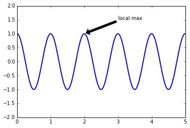

```python
ax = plt.subplot(111)

t = np.arange(0.0, 5.0, 0.01)
s = np.cos(2*np.pi*t)
line, = plt.plot(t, s, lw=2)

plt.annotate('local max', xy=(2, 1), xytext=(3, 1.5),
            arrowprops=dict(facecolor='black', shrink=0.05),
            )

plt.ylim(-2,2)
plt.show()
```